# Model-based diversity measure and plot checking

Shaoqian Huang

2026-09-15

## Aims

The document aims to check (1) if $\hat{\mu}_B^{\top}D\hat{\mu}_B$ can measure diversity correctly? $\hat{\mu}_B = g^{-1}(\hat{\eta}_B)$. (2) if we can project $\hat{\eta}_B$ onto the first two axes of $JSJ$ to visualize how relative abundance changes along gradients in a biplot.

## DGM

### Set up parameters

```r
r <- 128 # sample size in each com
p <- 5 # the number of species
q <- 6 # the number of communities
## Mean abundance
mu=matrix(c(0.8,0.2,0.8,0.2,0.8,0.2,0.8,0.8,0.2,0.8,0.8,0.8,0.2,0.2,0.8,0.8,0.8,0.8,0.2,0.2,2/3,1/9,2/3,1/9,2/3, 0.8, 0.2, 0.2, 0.8, 0.8),ncol=6)
rownames(mu)=LETTERS[1:5]
colnames(mu)=1:q
mu <- t(mu)
print(mu)
```

```
##           A         B         C         D         E
## 1 0.8000000 0.2000000 0.8000000 0.2000000 0.8000000
## 2 0.2000000 0.8000000 0.8000000 0.2000000 0.8000000
## 3 0.8000000 0.8000000 0.2000000 0.2000000 0.8000000
## 4 0.8000000 0.8000000 0.8000000 0.2000000 0.2000000
## 5 0.6666667 0.1111111 0.6666667 0.1111111 0.6666667
## 6 0.8000000 0.2000000 0.2000000 0.8000000 0.8000000
```

```r
## Logit scale of mean abundance
eta <- logit(mu)
print(eta)
```

```
##            A         B          C         D          E
## 1  1.3862944 -1.386294  1.3862944 -1.386294  1.3862944
## 2 -1.3862944  1.386294  1.3862944 -1.386294  1.3862944
## 3  1.3862944  1.386294 -1.3862944 -1.386294  1.3862944
## 4  1.3862944  1.386294  1.3862944 -1.386294 -1.3862944
## 5  0.6931472 -2.079442  0.6931472 -2.079442  0.6931472
## 6  1.3862944 -1.386294 -1.3862944  1.386294  1.3862944
```

```r
## Distance Matrix
D=matrix(c(0,1,2,3,4,1,0,2,3,4,2,2,0,3,4,3,3,3,0,4,4,4,4,4,0),ncol=5)
colnames(D)=rownames(D)=LETTERS[1:5]
print(D)
```

```
##   A B C D E
## A 0 1 2 3 4
## B 1 0 2 3 4
## C 2 2 0 3 4
## D 3 3 3 0 4
## E 4 4 4 4 0
```

```r
## An orthogonal projection matrix
J <- diag(rep(1, p)) -  1/p * matrix(1, p, p)
```

Based on David’s experiment, here I adopt Scenario 1 where there are 6 communities. Specifically, com 1 and com 2 have the same diversity, com 3 and com 4 decreases in diversity compared with com 1, com 5 retains the same level diversity as com 1 but decreases in overall abundance, and com 6 increases in diversity compared with com 1.

### Produce mean abundances with correlations

```r
## Mean abundance matrix
# Expand mu across sites
mu_site <- mu[rep(c(1 : q), each = r), ]

# Calculate variance and covariance matrix of u
S <- max(D) - D
mean <- rep(0, p)
sigma <- S

# Generate r * p multivariate normal samples
resi_corr <- rmvnorm(n = r * q, mean = mean, sigma = sigma)

# Linear predictors
eta_u_site <- logit(mu_site) + resi_corr

# Mean abundance matrix with correlations
mu_eta_u_site <- expit(eta_u_site)
```

I set the similarity matrix $S$ as the variance-covariance matrix of $u$, which induces correlations for multivariate GLM.

### Data Generation

```r
## Abundance matrix
abundance <- mu_eta_u_site
abundance[] <- rbinom(length(mu_eta_u_site), size = 1, prob = mu_eta_u_site)

# Create community factor (1:q repeated r times each)
com <- factor(rep(1:q, each=r))

# Combine abundance matrix and community labels into a data frame
yX <- data.frame(abundance, com)

## Long format abundance data
yX <- reshape(yX, direction = "long", varying = colnames(abundance),
              v.names = "y", timevar = "sp")

# Convert species column to factor
yX$sp <- factor(yX$sp)
```

## Modelling

```r
model <- glmmTMB (y ~ com * sp + rr(sp + 0 | id, 2),
                  family = 'binomial',
                  data = yX)
```

## Model-based Diversity Assessment

### Extract fixed and random effects

```r
## Estimates of fixed effects, eta_T
eta_T_hat <- predict(model,
                   type = "link",
                   re.form = NA)

# Arrange eta_T_hat into a matrix
eta_T_hat <- matrix(
  as.numeric(eta_T_hat),
  ncol = p,
  byrow = FALSE
)

# Estimates of row centered fixed effects, eta_B
eta_B_hat <- eta_T_hat %*% J

##  Estimates of conditional random effects on y
RR <- simulate_random_effects(model = model)
```

### Dose $\hat{\mu}_B^{\top}D\hat{\mu}_B$ can measure diversity correctly?

```r
## True diversity for reference
Div_TRUE <- rowSums(expit(eta %*% J) %*% D * expit(eta %*% J))
print(Div_TRUE)
```

```
##        1        2        3        4        5        6
## 15.53312 15.53312 14.64182 10.88779 15.53312 16.61324
```

```r
## Model-based diversity
Div_Model <- rowSums(expit(unique(eta_B_hat)) %*% D * expit(unique(eta_B_hat)))
print(Div_Model)
```

```
## [1] 15.28924 14.60086 14.42290 11.51594 15.47442 16.32854
```

The results show the comparison of $\mu_B^{\top}D\mu_B$ and $\hat{\mu}_B^{\top}D\hat{\mu}_B$. Except for variation caused by estimation, $\hat{\mu}_B^{\top}D\hat{\mu}_B$ satisfies the expectation that diversity keeps the same between com 1 and com 2, decreases gradually through com 3 and com 4, keeps the same at com 5 with com 1 by accounting overall abundance change, and increases at com 6 compared with com 1.

```r
## Produce boxplot for model-based diversity in each com
# Model-based Diversity Assessment
mu_eta_B_u_hat <- expit(eta_B_hat + RR)
Div_Model <-  rowSums(mu_eta_B_u_hat %*% D * mu_eta_B_u_hat)
Div_Model_data <- data.frame(
  group = com,
  value = Div_Model
)
Boxplot(data = Div_Model_data,
        group_levels = c(
          '1',
          '2',
          '3',
          '4',
          '5',
          '6'),
        ylab = "mu_B^{T}Dmu_B"
        )
```

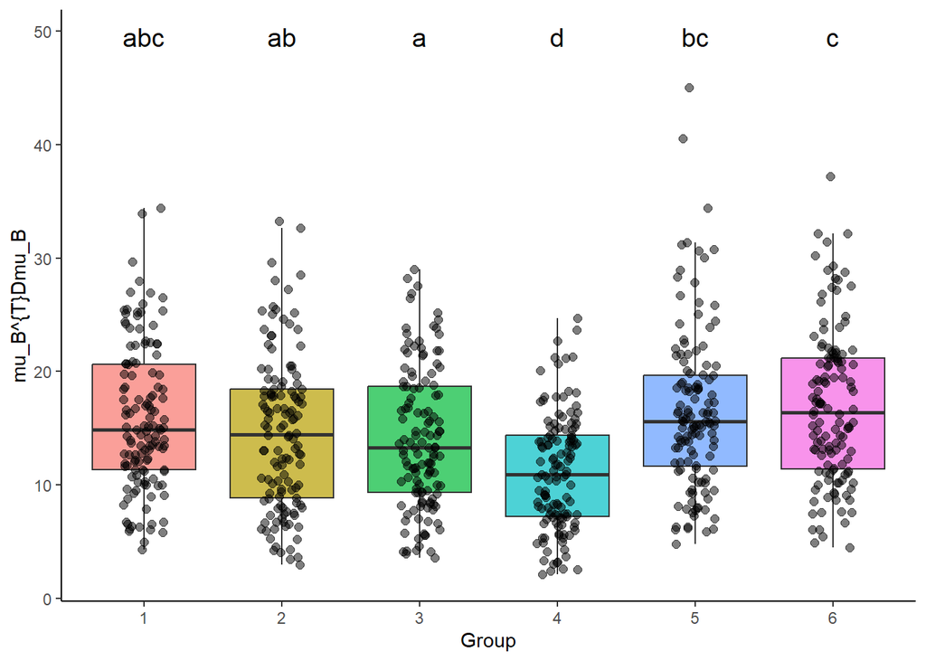

[figure not shown]